# Take-Home Portion

- data load
- OLS fit
- Plot data, model, error lines

## Problem 2: Streamflow Forecasting in Colorado River, TX. (50 points)

[figure not shown]

### The Colorado River is the 18th longest river in the United States and the longest river wholly located in Texas. The Colorado River originates from the Llano Estacado region in west Texas with an elevation of 1000 meters, flows southeast through eleven major reservoirs (e.g. Lake J.B. Thomas, E.V. Spence Reservoir and Lake O.H. Ivie) and eventually empties into the Gulf of Mexico near Matagorda. The river is considered as the life blood of Texas due to its essential role for the state’s economy, environment, agriculture, power production and developing municipalities and industries. The Colorado River begin its journey south of Lubbock as an intermittent stream. This means that there are periods where the riverbed goes dry and the flowrate is lower than measurable amounts.

[figure not shown]

### The "Colorado River Data.csv" dataset contains monthly streamflow recordings from 03/1988 to 03/2019 at USGS station #08117995 near Gail, Borden County, Texas as well as several hydro-meteorological variables from PRISM Climate Data:

| Columns | Info. |
| --- | --- |
| Date | Date of recording in YYYY-MM format |
| PPT | Accumulated Monthly Precipitation (mm) |
| Tmin | Minimum Recorded Temperature (degrees C) |
| Tav | Average Recorded Temperature (degrees C) |
| Tmax | Maximum Recorded Temperature (degrees C) |
| delt | Difference between Maximum and Minimum Recorded Temperatures (degrees C) |
| SMI | Soil Moisture Index (SMI) - The product of precipitation and average temperature |
| ET | Evapotranspiration (mm) |
| Flow_cfs | Average recorded flowrate (cfs) |
| Flow? | Flow status: It is 1 when there is a flow and it is 0 when there is no flow. |

### Follow the steps below and answer the associated questions:

```python
#Step0: Load the necessary libraries
import numpy as np
import pandas as pd
import statistics
import scipy.stats
import matplotlib.pyplot
from matplotlib import pyplot as plt
import seaborn as sns

import statsmodels.formula.api as smf
import sklearn.metrics as metrics
```

Step 1:

Read the "Colorado River Data.csv" file as a dataframe. Explore the dataframe and in a markdown cell breifly describe the different variables in your own words.

```python
#Step1:Read the "Colorado River Data.csv" file as a dataframe
df = pd.read_csv('Colorado River Data.csv')
df.head()
```

|  | Date | PPT | Tmin | Tav | Tmax | delt | SMI | ET | Flow_cfs | Flow? |
| --- | --- | --- | --- | --- | --- | --- | --- | --- | --- | --- |
| 0 | 1988-03 | 16.09 | 2.8 | 12.3 | 21.8 | 19.0 | 197.907 | 31.429845 | 2.68 | 1 |
| 1 | 1988-04 | 17.63 | 7.9 | 17.0 | 26.1 | 18.2 | 299.710 | 61.427057 | 2.33 | 1 |
| 2 | 1988-05 | 63.44 | 14.1 | 21.4 | 28.7 | 14.6 | 1357.616 | 104.931753 | 4.56 | 1 |
| 3 | 1988-06 | 58.01 | 18.6 | 25.8 | 33.0 | 14.4 | 1496.658 | 149.374517 | 18.20 | 1 |
| 4 | 1988-07 | 91.98 | 20.5 | 26.6 | 32.7 | 12.2 | 2446.668 | 161.751506 | 76.10 | 1 |

```python
# Explore the dataframe: Describe the df
df.describe()
```

|  | PPT | Tmin | Tav | Tmax | delt | SMI | ET | Flow_cfs | Flow? |
| --- | --- | --- | --- | --- | --- | --- | --- | --- | --- |
| count | 373.000000 | 373.000000 | 373.000000 | 373.000000 | 373.000000 | 373.000000 | 373.000000 | 373.000000 | 373.000000 |
| mean | 42.483217 | 10.456568 | 17.771046 | 25.087668 | 14.631099 | 862.258668 | 80.490330 | 13.153506 | 0.678284 |
| std | 42.894824 | 8.182669 | 7.896588 | 7.715736 | 1.889885 | 1014.255443 | 63.165859 | 51.729368 | 0.467762 |
| min | 0.000000 | -4.600000 | 3.300000 | 8.800000 | 9.900000 | 0.000000 | 2.151330 | 0.000000 | 0.000000 |
| 25% | 9.910000 | 2.500000 | 10.500000 | 18.200000 | 13.400000 | 126.100000 | 19.647938 | 0.000000 | 0.000000 |
| 50% | 30.700000 | 10.400000 | 18.100000 | 25.900000 | 14.500000 | 428.280000 | 65.127493 | 0.550000 | 1.000000 |
| 75% | 62.850000 | 18.400000 | 25.300000 | 31.800000 | 16.000000 | 1389.024000 | 138.843235 | 7.600000 | 1.000000 |
| max | 251.240000 | 24.300000 | 31.500000 | 38.800000 | 19.400000 | 5672.665000 | 218.125353 | 709.900000 | 1.000000 |

Step 2:

Get the following plots and analyze each one of them:

- Plot a histogram with KDE for precipitation. | What does it show? What are the most common value you expect to see based on this graph?
- Plot flow vs. date. | What are the most noteable things you see in this graph? What are some extreme values and why do you think they have happened?
- Plot a joint KDE plot with ET on x-axis and flow status on the y-axis.

What does this graph show you? Do you think evaporation can be a good predictor for flow status?

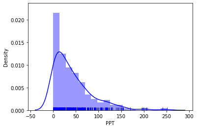

```python
#Step2-part A:
sns.distplot(df['PPT'], kde = True, rug= True, color ='blue')
```

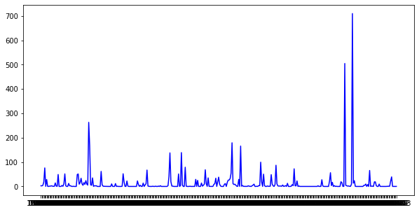

```python
#Step2-part B:
date = df['Date']
flow = df['Flow_cfs']

# Plot here
myfigure = matplotlib.pyplot.figure(figsize = (10,5)) # generate an object from the figure class, set aspect ratio

matplotlib.pyplot.plot(date,flow, color ='blue')
```

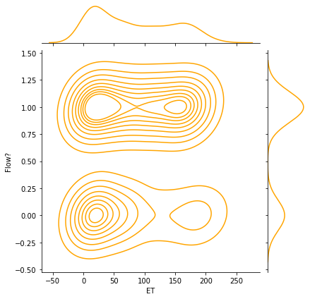

```python
#Step2-part C:
sns.jointplot(x ='ET', y ='Flow?', data = df, kind ='kde',color="orange")
```

Step 3:

Calculate and compare the correlation coefficient of the variables. Analyze the results and decide.

- which parameters have the strongest relationship and weakest relationship with the flowrates? Do you identify correlation and causation or just correlation?
- what predictor has the strongest relationship with ET?
- which parameter has a negative correlation with precipitation?

```python
#Step3: Calculate and compare the correlation coefficient
#What can we infer?
df.corr(method ='pearson')
```

|  | PPT | Tmin | Tav | Tmax | delt | SMI | ET | Flow_cfs | Flow? |
| --- | --- | --- | --- | --- | --- | --- | --- | --- | --- |
| PPT | 1.000000 | 0.377617 | 0.317593 | 0.249061 | -0.618147 | 0.938977 | 0.289487 | 0.614588 | 0.452067 |
| Tmin | 0.377617 | 1.000000 | 0.993709 | 0.973441 | -0.355501 | 0.572704 | 0.974184 | 0.151265 | 0.234497 |
| Tav | 0.317593 | 0.993709 | 1.000000 | 0.992938 | -0.248663 | 0.526083 | 0.975157 | 0.123433 | 0.197389 |
| Tmax | 0.249061 | 0.973441 | 0.992938 | 1.000000 | -0.132076 | 0.468836 | 0.962877 | 0.092345 | 0.155013 |
| delt | -0.618147 | -0.355501 | -0.248663 | -0.132076 | 1.000000 | -0.565551 | -0.286853 | -0.277924 | -0.382443 |
| SMI | 0.938977 | 0.572704 | 0.526083 | 0.468836 | -0.565551 | 1.000000 | 0.502235 | 0.575503 | 0.423881 |
| ET | 0.289487 | 0.974184 | 0.975157 | 0.962877 | -0.286853 | 0.502235 | 1.000000 | 0.101266 | 0.184756 |
| Flow_cfs | 0.614588 | 0.151265 | 0.123433 | 0.092345 | -0.277924 | 0.575503 | 0.101266 | 1.000000 | 0.175355 |
| Flow? | 0.452067 | 0.234497 | 0.197389 | 0.155013 | -0.382443 | 0.423881 | 0.184756 | 0.175355 | 1.000000 |

Step 4:

Think about a few enginreeing applications in which we may need to forecast the flowrate in a river?

```python
#Step4:
```

Step 5:

Use linear regression modeling in primitive python, get the linear model's coefficients via Ordinary Least Squares methods, make a plot and VISUALLY assess the quality of a linear fit with precipitation as the predictor, and flowrate as outcome. Then, use RMSE, Pearson's r, and R2 to describe the performance of your model. Explain the results of this analysis in a markdown cell.

```
alpha = -18.333691604121526
beta = 0.7411679241433508
```

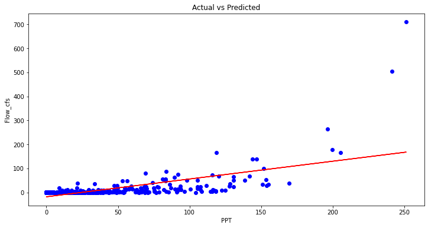

```
RMSE for PPT as predictor is  40.751870999819324
R2 for PPT as predictor is  0.37771885033965624
Pearson's r for PPT as predictor is  0.6145883584478773
```

```python
#Step5:
# Calculate the mean of X and y
xmean = np.mean(df['PPT'])
ymean = np.mean(df['Flow_cfs'])

# Calculate the terms needed for the numator and denominator of beta
df['xycov'] = (df['PPT'] - xmean) * (df['Flow_cfs'] - ymean)
df['xvar'] = (df['PPT'] - xmean)**2

# Calculate beta and alpha
beta = df['xycov'].sum() / df['xvar'].sum()
alpha = ymean - (beta * xmean)
print(f'alpha = {alpha}')
print(f'beta = {beta}')

X = np.array(df['PPT'])
Y = np.array(df['Flow_cfs'])

ypred = alpha + beta * X
# Plot regression against actual data
plt.figure(figsize=(12, 6))
plt.plot(X, Y, 'ro', color="blue")   # scatter plot showing actual data
plt.plot(X, ypred, color="red")     # regression line
plt.title('Actual vs Predicted')
plt.xlabel('PPT')
plt.ylabel('Flow_cfs')

plt.show()
###
#GOF metrics:
print("RMSE for PPT as predictor is ",np.sqrt(metrics.mean_squared_error(Y, ypred)))
print("R2 for PPT as predictor is ",metrics.r2_score(Y, ypred))

pearson_r = scipy.stats.pearsonr(ypred, Y)

print("Pearson's r for PPT as predictor is ",pearson_r[0])
```

Step 6:

Use multiple linear regression modeling with scikit-learn and use all "ET","SMI", and "delt" to predict the flowrates. Then, use RMSE, Pearson's r, and R2 to describe the performance of your model. Explain the results of this analysis in a markdown cell.

```python
#Step6:
from sklearn.linear_model import LinearRegression

# Split data into predictors X and output Y
predictors = ['ET', 'SMI', 'delt']
X = df[predictors]
Y = df['Flow_cfs']

# Initialise and fit model
lm = LinearRegression()
model = lm.fit(X, Y)

# Predict values
big_pred = model.predict(X)
#GOF metrics:
print("RMSE for PPT as predictor is ",np.sqrt(metrics.mean_squared_error(Y, big_pred)))
print("R2 for PPT as predictor is ",metrics.r2_score(Y, big_pred))

pearson_r = scipy.stats.pearsonr(big_pred, Y)

print("Pearson's r for PPT as predictor is ",pearson_r[0])
```

```
RMSE for PPT as predictor is  40.62517214384142
R2 for PPT as predictor is  0.38158221887758004
Pearson's r for PPT as predictor is  0.6177234161642087
```

Step 7:

Think about a few enginreeing applications in which we may need to forecast the flow status (flow/no flow) in a river?

```python
#Step7:
```

Step 8:

Use logistic regression and "PPT","SMI", and "delt" as predictors to predict the status of flow. Use a 75/25 split for training and testing. Then, get the confusion matrix and use classification_report to describe the performance of your model. Also, get a heatmap and visually assess the predictions of your model. Calculate accuracy, recall, precision, and F1-score for your model. Explain the results of this analysis in a markdown cell.

```
[[21 12]
 [13 48]]
Accuracy: 0.7340425531914894
Precision: 0.7868852459016393
Recall: 0.8
F1-score: 0.7933884297520661
              precision    recall  f1-score   support

           0       0.64      0.62      0.63        34
           1       0.79      0.80      0.79        60

    accuracy                           0.73        94
   macro avg       0.71      0.71      0.71        94
weighted avg       0.73      0.73      0.73        94
```

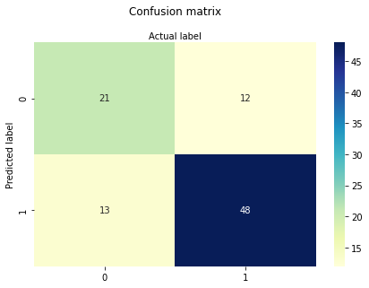

```python
#Step8:
#split dataset in features and target variable
feature_cols = ['PPT', 'SMI', 'delt']
X = df[feature_cols] # Features
Y = df['Flow?'] # Target variable
# split X and y into training and testing sets
from sklearn.model_selection import train_test_split
X_train,X_test,y_train,y_test=train_test_split(X,Y,test_size=0.25,random_state=0)
# import the class
from sklearn.linear_model import LogisticRegression

# instantiate the model (using the default parameters)
#logreg = LogisticRegression()
logreg = LogisticRegression()
# fit the model with data
logreg.fit(X_train,y_train)

#
y_pred=logreg.predict(X_test)

# import the metrics class
from sklearn import metrics
cnf_matrix = metrics.confusion_matrix(y_pred, y_test)
print(cnf_matrix)
# Visualize
class_names=[0,1] # name  of classes
fig, ax = plt.subplots()
tick_marks = np.arange(len(class_names))
plt.xticks(tick_marks, class_names)
plt.yticks(tick_marks, class_names)
# create heatmap
sns.heatmap(pd.DataFrame(cnf_matrix), annot=True, cmap="YlGnBu" ,fmt='g')
ax.xaxis.set_label_position("top")
plt.tight_layout()
plt.title('Confusion matrix', y=1.1)
plt.ylabel('Predicted label')
plt.xlabel('Actual label')
#
print("Accuracy:",metrics.accuracy_score(y_test, y_pred))
print("Precision:",metrics.precision_score(y_test, y_pred))
print("Recall:",metrics.recall_score(y_test, y_pred))
print("F1-score:",metrics.f1_score(y_test, y_pred))
#
from sklearn.metrics import classification_report

print(classification_report(y_test, y_pred))
```

Step 9:

Was this a balanced classification problem? why?

```python
#Step9:
```

## Take-Home Part | Alternatives for Bonus Questions

```python
- Step1: Read the "Colorado River Data.csv" file as a dataframe. Explore the dataframe and in a markdown cell breifly describe the different variables in your own words. <br>

- Step2: Get the following plots and analyze each one of them:
    - Plot a histogram with KDE for precipitation. | What does it show? What are the most common value you expect to see based on this graph?
    - Plot flow vs. date. | What are the most noteable things you see in this graph? What are some extreme values and why do you think they have happened?
    - Plot a joint KDE plot with ET on x-axis and flow status on the y-axis. |What does this graph show you? Do you think evaporation can be a good predictor for flow status?

- Step3: Calculate and compare the correlation coefficient of the variables. Analyze the results and decide.
    - which parameters have the strongest relationship and weakest relationship with the flowrates? Do you identify correlation and causation or just correlation?
    - what predictor has the strongest relationship with ET?
    - which parameter has a negative correlation with precipitation?

- Step4: Think about a few enginreeing applications in which we may need to forecast the flowrate in a river?

- Step5: Use linear regression modeling in primitive python, get the linear model's coefficients via Ordinary Least Squares methods, make a plot and VISUALLY assess the quality of a linear fit with precipitation as the predictor, and flowrate as outcome. Then, use RMSE, Pearson's r, and R2 to describe the performance of your model. Explain the results of this analysis in a markdown cell.

- Step6: Use multiple linear regression modeling with scikit-learn and use all "ET","SMI", and "delt" to predict the flowrates. Then, use RMSE, Pearson's r, and R2 to describe the performance of your model. Explain the results of this analysis in a markdown cell.

- Step7: Think about a few enginreeing applications in which we may need to forecast the flow status (flow/no flow) in a river?

- Step8: Use logistic regression and "PPT","SMI", and "delt" as predictors to predict the status of flow. Use a 75/25 split for training and testing. Then, get the confusion matrix and use classification_report to describe the performance of your model. Also, get a heatmap and visually assess the predictions of your model. Calculate accuracy, recall, precision, and F1-score for your model. Explain the results of this analysis in a markdown cell.


- Step9: Was this a balanced classification problem? why?
```